# Transcript EDA

This notebook is an EDA of transcripts to assess the data quality and robustness so that we know what steps to take going into topic modelling. There are summary statistics, tf-idf, bigram, and trigram analyses, followed by my quick takeaways.

```r
setwd("~/dev/capstone")
```

## Import Libraries

```r
library(tidytext)
```

[output not shown]

## Data

I used Google Colab to upload all the transcripts and organize them into a dataframe (exported as csv) where each row is a document and the columns are the filename and the contents of that .txt file.

```r
df <- read.csv('transcripts_df.csv')
```

```r
df_tibble <- tibble(df)
df_tibble <- mutate(df_tibble, text = as.character(contents))
```

## Summary Statistics

```r
#number of documents
nrow(df)
```

```
[1] 109
```

```r
words <- df_tibble%>%
  unnest_tokens(word, text) %>%
  count(file_name, word, sort = TRUE)

total_words <- words %>%
  group_by(file_name) %>%
  summarize(total = sum(n))

transcript_words <- left_join(words, total_words)
```

```r
total_words %>% arrange(desc(total))
```

| file_name | total |
| --- | --- |
| Ask the Mentor Q_A Call on Deals and Deal Structure with Robert Helms_otter_ai.txt | 14780 |
| Copy of Ask the Mentor Q_A Call on Deals and Deal Structure with Robert Helms_otter_ai.txt | 14780 |
| June 2021 - Ask the Mentors Q_A Call on Legal and Compliance with Russell Gray and Mauricio Rauld_otter_ai.txt | 13695 |
| October-2021-Ask-the-Mentors-Q_A-Call-on-Legal-_-Compliance-with-Russell-Gray-and-Mauricio-Rauld.txt | 13606 |
| August 2021 - Ask the Mentors Q_A Call on Lending with Russell Gray and Stephanie Riley.txt | 13107 |
| CC - July 29, 2020 - Q_A LIVE Call on Sales and Marketing with Russell Gray and Staci Gray_otter_ai.txt | 12968 |
| July 2021 - Ask the Mentors Q_A Call on Sales and Marketing with Russell Gray and Staci Gray_otter_ai.txt | 12933 |
| December 2020 - Ask the Mentors Q_A Call on Clues in the News with Russell Gray_otter_ai.txt | 12840 |
| September-2021-Ask-the-Mentors-Q_A-Call-on-Sales-and-Marketing-with-Russell Gray-and-Staci-Gray.txt | 12574 |
| August 19, 2020 - Q_A LIVE Call on Legal and Compliance with Russell Gray and Mauricio Rauld, Esq._otter_ai.txt | 12502 |

[output cut: 99 more lines]

```r
mean(total_words$total)
```

```
[1] 10923.83
```

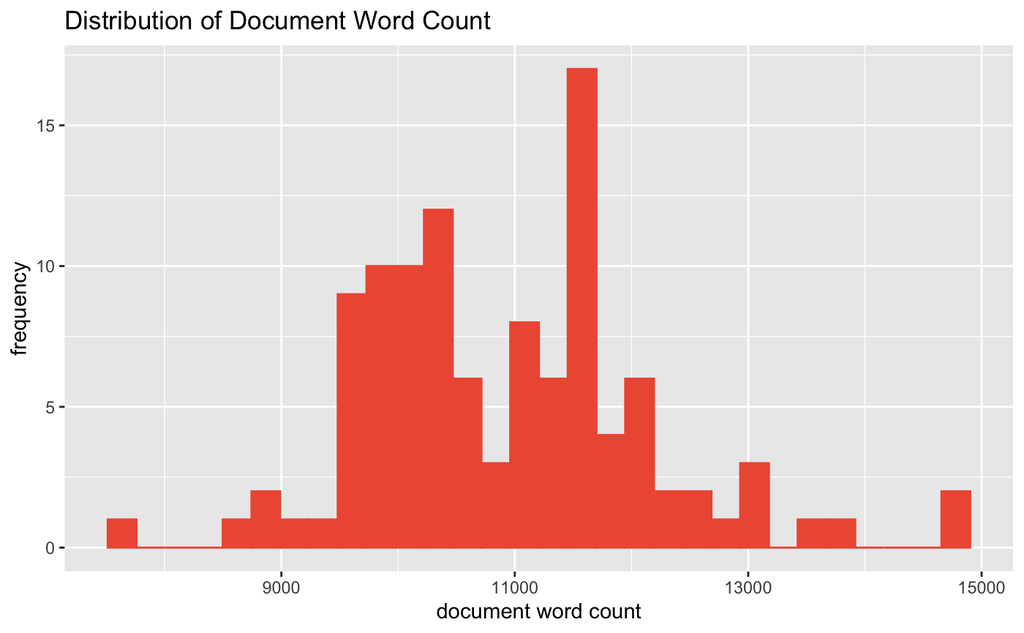

```r
ggplot(total_words, aes(x=total)) +
  geom_histogram(color="tomato2", fill="tomato2") +
  labs(title='Distribution of Document Word Count', y='frequency', x='document word count')
```

### TF-IDF

```r
transcript_tf_idf <- transcript_words %>%
  bind_tf_idf(word, file_name, n)
```

```r
transcript_tf_idf %>%
  select(-total) %>%
  arrange(desc(tf_idf))
```

| file_name | word | n | tf | idf | tf_idf |
| --- | --- | --- | --- | --- | --- |
| Ask the Mentors Q_A on Market Analysis with Robert Helms, Russell Gray and Ingo Winzer_otter_ai.txt | ingo | 36 | 0.0032479249 | 3.9982007 | 0.012985856 |
| George+Ross+June+2020_otter.ai.txt | franchise | 40 | 0.0039373954 | 2.8995884 | 0.011416826 |
| November-2021-Ask-the-Mentors-Q_A-Call-on-Lending-with-Russell-Gray,-Stephanie-Riley-and-Anton-Mattli.txt | anton | 34 | 0.0033448106 | 2.8995884 | 0.009698574 |
| Audio September 2021 - Ask the Mentors Q_A Call on Accounting and Tax with Russell Gray and Mike Pine_otter.ai.txt | depreciation | 63 | 0.0056552962 | 1.6956156 | 0.009589209 |
| Audio - August 2021 - Ask the Mentors Q_A Call on Asset and Estate Planning with Russell Gray and Kevin Day.txt | kevin | 55 | 0.0055752661 | 1.6003054 | 0.008922129 |
| PC - December 2020 - Mastermind with George Ross_otter_ai.txt | wholesaler | 24 | 0.0023589542 | 3.5927356 | 0.008475099 |
| December-2021-Ask-the-Mentors-Q_A-Call-on-Asset-and-Estate-Planning-with-Russell-Gray-and-Kevin-Day.txt | kevin | 54 | 0.0052391579 | 1.6003054 | 0.008384253 |
| September 2021 - Ask the Mentors Q_A Call on Lending with Russell Gray and Anton Mattli.txt | anton | 28 | 0.0028848135 | 2.8995884 | 0.008364772 |
| July 2021 - Ask the Mentors Q_A Call on Clues in the News with Russell Gray_otter_ai.txt | repo | 23 | 0.0020771245 | 3.9982007 | 0.008304761 |
| Audio September 2021 - Ask the Mentors Q_A Call on Accounting and Tax with Russell Gray and Mike Pine_otter.ai.txt | segregation | 33 | 0.0029622980 | 2.7454377 | 0.008132805 |

[output cut: 990 more lines]

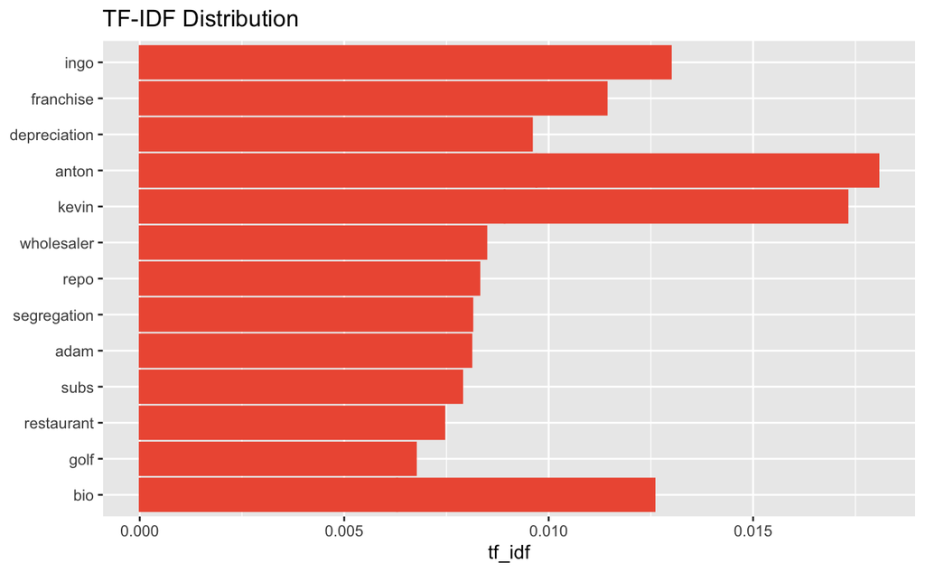

```r
transcript_tf_idf %>%
  select(-total) %>%
  #ungroup() %>%
  arrange(desc(tf_idf)) %>%
  slice_max(tf_idf, n = 15) %>%
  ggplot(aes(fct_reorder(word, tf_idf), tf_idf)) +
  geom_col(color='tomato2', fill='tomato2') +
  coord_flip() +
  labs(x = NULL, title='TF-IDF Distribution')
```

## Bigrams

```r
transcript_bigrams <- df_tibble %>%
  unnest_tokens(bigram, text, token = "ngrams", n = 2)
```

```r
bigrams_separated <- transcript_bigrams %>%
  separate(bigram, c("word1", "word2"), sep = " ")

bigrams_filtered <- bigrams_separated %>%
  filter(!word1 %in% stop_words$word) %>%
  filter(!word2 %in% stop_words$word)

# new bigram counts:
bigram_counts <- bigrams_filtered %>%
  count(word1, word2, sort = TRUE)

bigrams_united <- bigrams_filtered %>%
  unite(bigram, word1, word2, sep = " ")
```

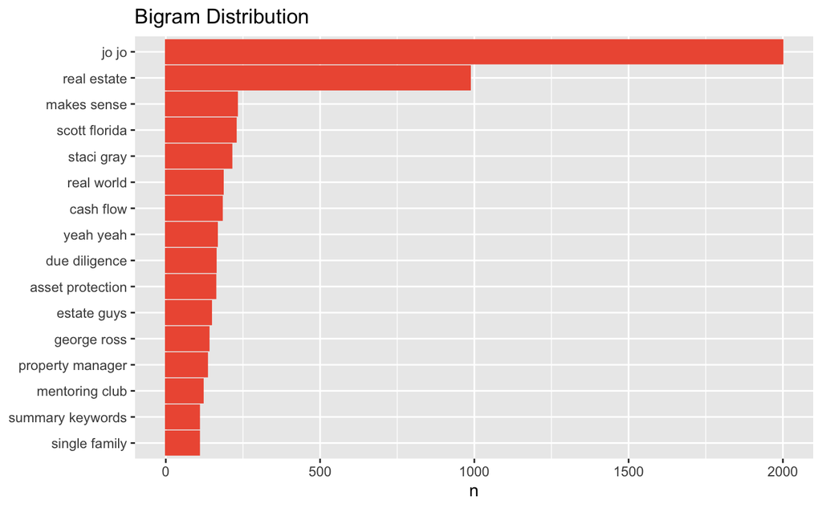

```r
bigrams_united %>%
    count(bigram, sort = TRUE) %>%
    top_n(15) %>%
    ggplot(aes(fct_reorder(bigram, n), n)) +
    geom_col(color='tomato2', fill='tomato2') +
    coord_flip() +
    labs(x = NULL, title='Bigram Distribution')
```

## Trigrams

```r
transcript_trigrams <- df_tibble %>%
  unnest_tokens(trigram, text, token = "ngrams", n = 3)
```

```r
trigrams_separated <- transcript_trigrams %>%
  separate(trigram, c("word1", "word2", "word3"), sep = " ")

trigrams_filtered <- trigrams_separated %>%
  filter(!word1 %in% stop_words$word) %>%
  filter(!word2 %in% stop_words$word) %>%
  filter(!word3 %in% stop_words$word)

# new bigram counts:
trigram_counts <- trigrams_filtered %>%
  count(word1, word2, word3, sort = TRUE)

trigrams_united <- trigrams_filtered %>%
  unite(trigram, word1, word2, word3, sep = " ")
```

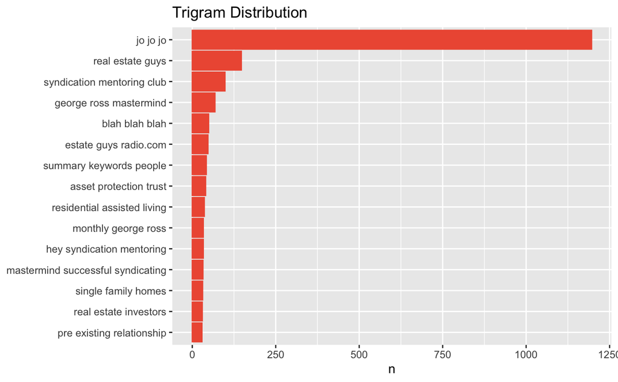

```r
trigrams_united %>%
    count(trigram, sort = TRUE) %>%
    top_n(15) %>%
    ggplot(aes(fct_reorder(trigram, n), n)) +
    geom_col(color='tomato2', fill='tomato2') +
    coord_flip() +
    labs(x = NULL, title='Trigram Distribution')
```

## Takeaways

- There transcripts are sizeable, giving us a lot of data (over 1 million words) to work with even if we don’t have a lot of documents (109). The content of those documents is robust, but needs a lot of cleaning and refining due to the nature of the transcription software and domain-specific stopwords.
  - A list of words we should count as stop words that are specific to REG/SMC and even more broadly to real estate will be needed.
  - There seem to be a lot of weird words, probably due to the transcription software.
  - The top words and phrases seem to be a mix of real estate topics, people’s names, REG/SMC naming, and odd words that may be a result of transcription software issues.